# Financial Analytics data

```python
import pandas as pd
import numpy as np
import matplotlib.pyplot as plt
import seaborn as sns
```

```python
#df = pd.read_csv(r"E:\DATA_SCIENCE\Desktop\UNIFIED\Data Science Projects\Financial Analytics data.csv")
```

```python
df.head()
```

[output not shown]

```python
df.drop(columns=['S.No.'],inplace=True)
```

```python
df
```

|  | Name | Mar Cap - Crore | Sales Qtr - Crore |
| --- | --- | --- | --- |
| 0 | Info Edg.(India) | 14845.05 | NaN |
| 1 | Mahindra CIE | 8587.04 | NaN |
| 2 | Prism Cement | 6176.23 | NaN |
| 3 | GE Power | 5497.40 | NaN |
| 4 | MMTC | 5300.00 | NaN |
| ... | ... | ... | ... |
| 483 | Shriram Pistons | 3804.58 | 430.8 |
| 484 | IFCI | 3789.45 | 626.8 |
| 485 | Force Motors | NaN | NaN |
| 486 | JP Power Ven. | 3597.60 | NaN |
| 487 | L T Foods | NaN | NaN |

488 rows × 3 columns

```python
df.describe()
```

|  | Mar Cap - Crore | Sales Qtr - Crore |
| --- | --- | --- |
| count | 479.000000 | 459.000000 |
| mean | 28043.857119 | 3807.789412 |
| std | 59464.615831 | 9989.449987 |
| min | 3017.070000 | 0.000000 |
| 25% | 4843.575000 | 534.910000 |
| 50% | 9885.050000 | 1137.170000 |
| 75% | 23549.900000 | 2730.195000 |
| max | 583436.720000 | 110666.930000 |

```python
df.info()
```

```
<class 'pandas.core.frame.DataFrame'>
RangeIndex: 488 entries, 0 to 487
Data columns (total 3 columns):
 #   Column             Non-Null Count  Dtype
---  ------             --------------  -----
 0   Name               488 non-null    object
 1   Mar Cap - Crore    479 non-null    float64
 2   Sales Qtr - Crore  459 non-null    float64
dtypes: float64(2), object(1)
memory usage: 11.6+ KB
```

```python
df.isnull().sum()
```

```
Name                  0
Mar Cap - Crore       9
Sales Qtr - Crore    29
dtype: int64
```

```python
# Count the missing values in Sales Qtr - Crore
missing_sales = df['Sales Qtr - Crore'].isna().sum()
print(f"\nMissing values in 'Sales Qtr - Crore': {missing_sales}")
```

```
Missing values in 'Sales Qtr - Crore': 29
```

### There are 29 missing values in the "Sales Qtr - Crore" column.

```python
df[df['Sales Qtr - Crore'].isna()]
```

|  | Name | Mar Cap - Crore | Sales Qtr - Crore |
| --- | --- | --- | --- |
| 0 | Info Edg.(India) | 14845.05 | NaN |
| 1 | Mahindra CIE | 8587.04 | NaN |
| 2 | Prism Cement | 6176.23 | NaN |
| 3 | GE Power | 5497.40 | NaN |
| 4 | MMTC | 5300.00 | NaN |
| 5 | Amber Enterp. | 3529.87 | NaN |
| 6 | Hind.Construct. | 3452.57 | NaN |
| 372 | Bharti Infra. | 61776.92 | NaN |
| 410 | Colgate-Palm. | NaN | NaN |
| 411 | Endurance Tech. | NaN | NaN |
| 413 | Max Financial | 13401.76 | NaN |
| 415 | Natl. Aluminium | NaN | NaN |
| 426 | Bombay Burmah | 10864.53 | NaN |
| 436 | Sundaram Clayton | 10074.36 | NaN |
| 437 | Mahanagar Gas | NaN | NaN |
| 442 | Bajaj Corp | NaN | NaN |
| 443 | ISGEC Heavy | NaN | NaN |
| 445 | Swan Energy | 4721.49 | NaN |
| 449 | Shoppers St. | 4558.06 | NaN |
| 452 | Stand.Chart.PLC | 4487.31 | NaN |
| 459 | BSE | NaN | NaN |
| 467 | Jindal Saw | 4278.31 | NaN |
| 469 | Linde India | 4198.33 | NaN |
| 477 | JP Associates | 4074.37 | NaN |
| 479 | HMT | 3973.50 | NaN |
| 481 | Gayatri Projects | 3835.73 | NaN |
| 485 | Force Motors | NaN | NaN |
| 486 | JP Power Ven. | 3597.60 | NaN |
| 487 | L T Foods | NaN | NaN |

```python
df[df['Mar Cap - Crore'].isna()]
```

|  | Name | Mar Cap - Crore | Sales Qtr - Crore |
| --- | --- | --- | --- |
| 410 | Colgate-Palm. | NaN | NaN |
| 411 | Endurance Tech. | NaN | NaN |
| 415 | Natl. Aluminium | NaN | NaN |
| 437 | Mahanagar Gas | NaN | NaN |
| 442 | Bajaj Corp | NaN | NaN |
| 443 | ISGEC Heavy | NaN | NaN |
| 459 | BSE | NaN | NaN |
| 485 | Force Motors | NaN | NaN |
| 487 | L T Foods | NaN | NaN |

```python
df.dropna(inplace=True)
```

```python
df.head()
```

|  | Name | Mar Cap - Crore | Sales Qtr - Crore |
| --- | --- | --- | --- |
| 7 | I O C L | 178017.48 | 110666.93 |
| 8 | Reliance Inds. | 583436.72 | 99810.00 |
| 9 | Tata Motors | 117071.87 | 74156.07 |
| 10 | B P C L | 98278.00 | 60616.36 |
| 11 | H P C L | 58034.78 | 57474.25 |

```python
df = df.reset_index(drop=True)
```

```python
df.head()
```

|  | Name | Mar Cap - Crore | Sales Qtr - Crore |
| --- | --- | --- | --- |
| 0 | I O C L | 178017.48 | 110666.93 |
| 1 | Reliance Inds. | 583436.72 | 99810.00 |
| 2 | Tata Motors | 117071.87 | 74156.07 |
| 3 | B P C L | 98278.00 | 60616.36 |
| 4 | H P C L | 58034.78 | 57474.25 |

```python
df.info()
```

```
<class 'pandas.core.frame.DataFrame'>
RangeIndex: 459 entries, 0 to 458
Data columns (total 3 columns):
 #   Column             Non-Null Count  Dtype
---  ------             --------------  -----
 0   Name               459 non-null    object
 1   Mar Cap - Crore    459 non-null    float64
 2   Sales Qtr - Crore  459 non-null    float64
dtypes: float64(2), object(1)
memory usage: 10.9+ KB
```

```python
df['Name'].nunique()
```

```
459
```

```python
# df['Name'].unique()
```

```python
df.columns
```

```
Index(['Name', 'Mar Cap - Crore', 'Sales Qtr - Crore'], dtype='object')
```

```python
df.head()
```

|  | Name | Mar Cap - Crore | Sales Qtr - Crore |
| --- | --- | --- | --- |
| 0 | I O C L | 178017.48 | 110666.93 |
| 1 | Reliance Inds. | 583436.72 | 99810.00 |
| 2 | Tata Motors | 117071.87 | 74156.07 |
| 3 | B P C L | 98278.00 | 60616.36 |
| 4 | H P C L | 58034.78 | 57474.25 |

```python
df.to_csv(r"E:\DATA_SCIENCE\Desktop\UNIFIED\Data Science Projects\Financial Analytics data.csv")
```

# Univariat Analysis

```python
df['Mar Cap - Crore'].max()
```

```
583436.72
```

```python
df['Mar Cap - Crore'].min()
```

```
3017.07
```

```python
df['Mar Cap - Crore'].describe()
```

```
count       459.000000
mean      28870.974139
std       60557.081792
min        3017.070000
25%        4942.815000
50%       10442.090000
75%       24707.320000
max      583436.720000
Name: Mar Cap - Crore, dtype: float64
```

```python
df[df['Mar Cap - Crore'] == df['Mar Cap - Crore'].min()]
```

|  | Name | Mar Cap - Crore | Sales Qtr - Crore |
| --- | --- | --- | --- |
| 91 | Natl.Fertilizer | 3017.07 | 2840.75 |

```python
df[df['Mar Cap - Crore'] == df['Mar Cap - Crore'].max()]
```

|  | Name | Mar Cap - Crore | Sales Qtr - Crore |
| --- | --- | --- | --- |
| 1 | Reliance Inds. | 583436.72 | 99810.0 |

#### - The minimum market capitalization is ₹3,017 crore for the company National Fertilizer.

#### - The maximum market capitalization is ₹5,83,436 crore for the company Reliance Industries.

#### - 50% of the companies have a market capitalization of ₹10,442 crore.

```python
df['Sales Qtr - Crore'].describe()
```

```
count       459.000000
mean       3807.789412
std        9989.449987
min           0.000000
25%         534.910000
50%        1137.170000
75%        2730.195000
max      110666.930000
Name: Sales Qtr - Crore, dtype: float64
```

```python
df[df['Sales Qtr - Crore'] == df['Sales Qtr - Crore'].min()] # zero might be an outlier
```

|  | Name | Mar Cap - Crore | Sales Qtr - Crore |
| --- | --- | --- | --- |
| 443 | Ujjivan Fin.Ser. | 4293.42 | 0.0 |

```python
df[df['Sales Qtr - Crore'] == df['Sales Qtr - Crore'].max()]
```

|  | Name | Mar Cap - Crore | Sales Qtr - Crore |
| --- | --- | --- | --- |
| 0 | I O C L | 178017.48 | 110666.93 |

#### - The minimum quarterly sales is ₹0.0 crore for the company Ujjivan Fin.Ser.

#### - The maximum quarterly sales is ₹1,10,666 crore for the company I O C L.

#### - 50% of the companies have a quarterly sales of ₹1,137 crore.

```python
dt = df.iloc[0:,1:]
```

```
{'whiskers': [<matplotlib.lines.Line2D at 0x2a1225b70d0>,
 'caps': [<matplotlib.lines.Line2D at 0x2a1225c8990>,
 'boxes': [<matplotlib.lines.Line2D at 0x2a1225b63d0>,
 'medians': [<matplotlib.lines.Line2D at 0x2a1225ca090>,
 'fliers': [<matplotlib.lines.Line2D at 0x2a1225cab90>,
 'means': []}
```

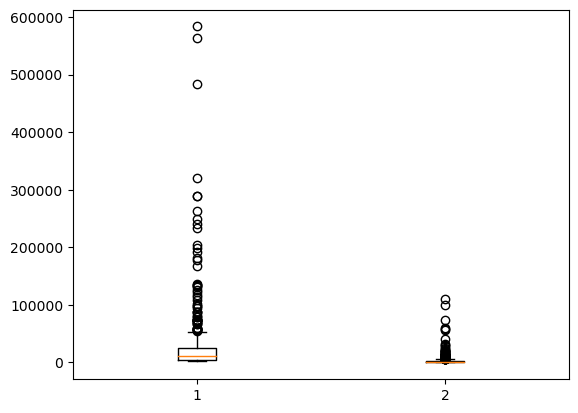

```python
plt.boxplot(dt)
```

```python
df[df['Mar Cap - Crore'] >= 300000]
```

|  | Name | Mar Cap - Crore | Sales Qtr - Crore |
| --- | --- | --- | --- |
| 1 | Reliance Inds. | 583436.72 | 99810.00 |
| 8 | TCS | 563709.84 | 30904.00 |
| 14 | HDFC Bank | 482953.59 | 20581.27 |
| 37 | ITC | 320985.27 | 9772.02 |

```python
dt1 = df[df['Mar Cap - Crore'] <= 300000]
dt1
```

|  | Name | Mar Cap - Crore | Sales Qtr - Crore |
| --- | --- | --- | --- |
| 0 | I O C L | 178017.48 | 110666.93 |
| 2 | Tata Motors | 117071.87 | 74156.07 |
| 3 | B P C L | 98278.00 | 60616.36 |
| 4 | H P C L | 58034.78 | 57474.25 |
| 5 | St Bk of India | 232763.33 | 57014.08 |
| ... | ... | ... | ... |
| 454 | Minda Corp | 3974.83 | 636.20 |
| 455 | Multi Comm. Exc. | 3847.19 | 60.97 |
| 456 | ICRA | 3809.00 | 82.87 |
| 457 | Shriram Pistons | 3804.58 | 430.80 |
| 458 | IFCI | 3789.45 | 626.80 |

455 rows × 3 columns

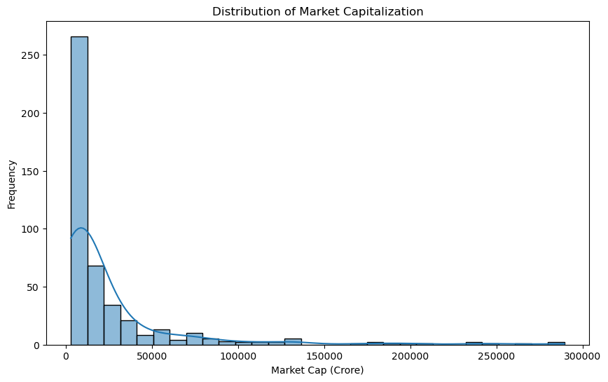

```python
plt.figure(figsize=(10, 6))
sns.histplot(dt1['Mar Cap - Crore'], kde=True, bins=30)
plt.title('Distribution of Market Capitalization')
plt.xlabel('Market Cap (Crore)')
plt.ylabel('Frequency')
plt.show()
```

```python
df.describe()
```

|  | Mar Cap - Crore | Sales Qtr - Crore |
| --- | --- | --- |
| count | 459.000000 | 459.000000 |
| mean | 28870.974139 | 3807.789412 |
| std | 60557.081792 | 9989.449987 |
| min | 3017.070000 | 0.000000 |
| 25% | 4942.815000 | 534.910000 |
| 50% | 10442.090000 | 1137.170000 |
| 75% | 24707.320000 | 2730.195000 |
| max | 583436.720000 | 110666.930000 |

```python
dt1.describe()
```

|  | Mar Cap - Crore | Sales Qtr - Crore |
| --- | --- | --- |
| count | 455.000000 | 455.000000 |
| mean | 24836.685077 | 3487.270440 |
| std | 41636.047400 | 8828.907123 |
| min | 3017.070000 | 0.000000 |
| 25% | 4926.500000 | 533.215000 |
| 50% | 10338.400000 | 1106.310000 |
| 75% | 23641.185000 | 2638.245000 |
| max | 289497.370000 | 110666.930000 |

```python
dt1.info()
```

```
<class 'pandas.core.frame.DataFrame'>
Index: 455 entries, 0 to 458
Data columns (total 3 columns):
 #   Column             Non-Null Count  Dtype
---  ------             --------------  -----
 0   Name               455 non-null    object
 1   Mar Cap - Crore    455 non-null    float64
 2   Sales Qtr - Crore  455 non-null    float64
dtypes: float64(2), object(1)
memory usage: 14.2+ KB
```

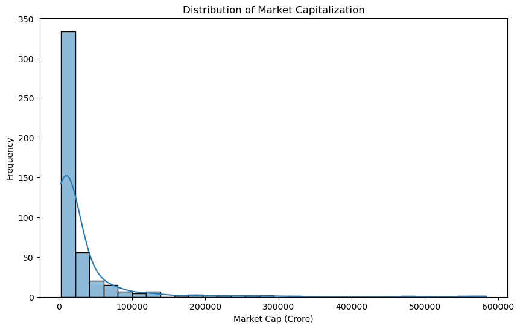

```python
# 1. Distribution of Market Cap
plt.figure(figsize=(10, 6))
sns.histplot(df['Mar Cap - Crore'], kde=True, bins=30)
plt.title('Distribution of Market Capitalization')
plt.xlabel('Market Cap (Crore)')
plt.ylabel('Frequency')
plt.show()
```

```python
# 2. Summary Statistics for Sales
print("Summary Statistics for Sales Qtr - Crore:")
data['Sales Qtr - Crore'].describe()
```

```
Summary Statistics for Sales Qtr - Crore:
```

```
count       459.000000
mean       3807.789412
std        9989.449987
min           0.000000
25%         534.910000
50%        1137.170000
75%        2730.195000
max      110666.930000
Name: Sales Qtr - Crore, dtype: float64
```

## BIVARIATE ANALYSIS

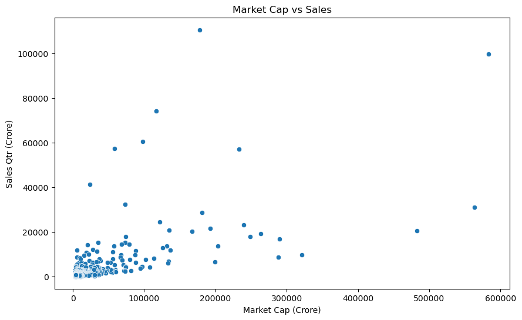

```python
# Scatter Plot: Market Cap vs Sales
plt.figure(figsize=(10, 6))
sns.scatterplot(x='Mar Cap - Crore', y='Sales Qtr - Crore', data=df)
plt.title('Market Cap vs Sales')
plt.xlabel('Market Cap (Crore)')
plt.ylabel('Sales Qtr (Crore)')
plt.show()
```

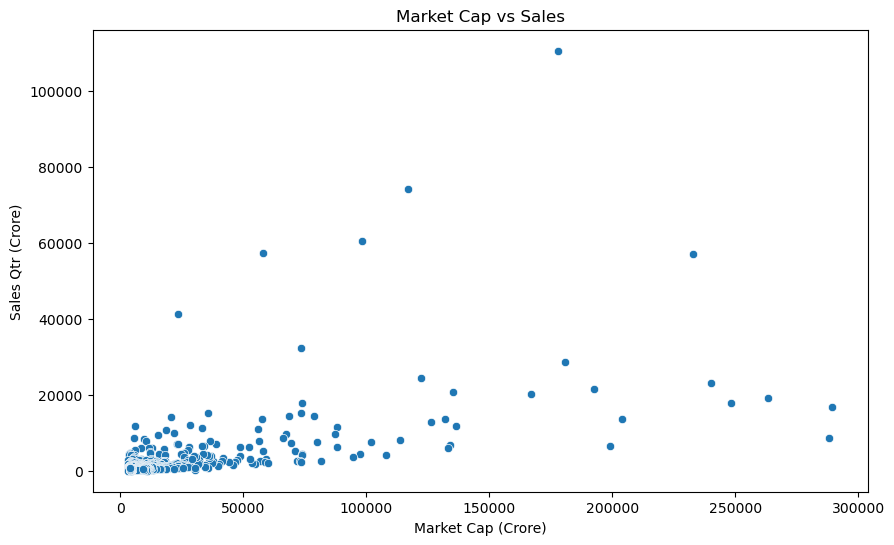

```python
# Scatter Plot: Market Cap vs Sales
plt.figure(figsize=(10, 6))
sns.scatterplot(x='Mar Cap - Crore', y='Sales Qtr - Crore', data=dt1)
plt.title('Market Cap vs Sales')
plt.xlabel('Market Cap (Crore)')
plt.ylabel('Sales Qtr (Crore)')
plt.show()
```

```python
correlation = data[['Mar Cap - Crore', 'Sales Qtr - Crore']].corr()
print("\nCorrelation between Market Cap and Sales:")
correlation
```

```
Correlation between Market Cap and Sales:
```

|  | Mar Cap - Crore | Sales Qtr - Crore |
| --- | --- | --- |
| Mar Cap - Crore | 1.000000 | 0.624409 |
| Sales Qtr - Crore | 0.624409 | 1.000000 |

#### - The correlation between Market Capitalization and Sales for the Quarter is 0.624, indicating a moderate positive relationship.

#### - This suggests that companies with higher market capitalization tend to have higher sales, but this is not a strict rule.

### Key Insights:

##### Positive Correlation: The moderate positive correlation between market cap and sales suggests that while larger companies tend to generate more revenue, other factors likely influence this relationship, as not all companies with high market caps have correspondingly high sales.

##### Distribution Observations: Both market cap and sales distributions are right-skewed, indicating a wide disparity among companies, with a few very large companies significantly influencing the overall averages.

###### Data Gaps: The presence of missing sales data should be addressed, as it may impact the robustness of any further analysis.

#### Recommendations:To gain deeper insights, it might be useful to segment the companies by industry or size and explore relationships within those segments.